# Week-2 Tasks

### Week-② Tasks By Abdullah Imran

- **Objective:** Implement a k-NN classifier from scratch.
- **Dataset:** Iris dataset.
- **Steps:**
  1. Load and preprocess the Iris dataset.
  2. Implement the k-NN algorithm.
  3. Test the classifier on the Iris dataset.
- **Expected Output:** A working k-NN classifier with performance metrics.

## `🌲 Task 3: Implement a Random Forest Classifier with Hyperparameter Tuning`

- **Objective:** Implement a random forest classifier.
- **Tools:** Scikit-learn, Grid Search CV.
- **Steps:**
  1. Load the dataset.
  2. Train the random forest classifier.
  3. Perform hyperparameter tuning using Grid Search CV.
  4. Evaluate the optimal parameters.
- **Expected Output:** A tuned random forest classifier with optimal parameters.

## `🐱‍💻 Task 4: Train a Support Vector Machine (SVM) Classifier on a Complex Dataset`

- **Objective:** Train an SVM classifier.
- **Steps:**
  1. Load and preprocess a complex dataset.
  2. Train the SVM classifier.
  3. Visualize the decision boundary.
- **Expected Output:** A trained SVM classifier with a visualized decision boundary.

## `📊 Task 5: Compare the Performance of Different Classifiers`

- **Objective:** Compare logistic regression, SVM, and random forest classifiers.
- **Metrics:** Accuracy, precision, recall, F1-score, and ROC-AUC.
- **Steps:**
  1. Load the dataset.
  2. Train logistic regression, SVM, and random forest classifiers.
  3. Evaluate and compare the performance using various metrics.
- **Expected Output:** A comparative analysis of classifier performance.

### Question No. 1️⃣

```python
import numpy as np
import pandas as pd
from sklearn.model_selection import train_test_split
from sklearn.preprocessing import MinMaxScaler
import matplotlib.pyplot as plt
%matplotlib inline

class KNN:
    def __init__(self, k=3):
        self.k = k

    def fit(self, X_train, y_train):
        self.X_train = X_train
        self.y_train = y_train

    def predict(self, X):
        # Calculate the Euclidean distances between X and all examples in the training set
        distances = np.linalg.norm(self.X_train[:, np.newaxis] - X, axis=2)
        # Get the indices of the k nearest neighbors
        k_indices = np.argsort(distances, axis=0)[:self.k]
        # Get the labels of the k nearest neighbors
        k_nearest_labels = self.y_train[k_indices]
        # Majority vote, most common class label
        y_pred = [Counter(labels).most_common(1)[0][0] for labels in k_nearest_labels.T]
        return np.array(y_pred)
```

```python
# Load the iris dataset
iris = pd.read_csv(r"D:\Projects\Python\CodeSoft Internship\Iris_Project\IRIS.csv")
```

```python
iris.head()
```

|  | sepal_length | sepal_width | petal_length | petal_width | species |
| --- | --- | --- | --- | --- | --- |
| 0 | 5.1 | 3.5 | 1.4 | 0.2 | Iris-setosa |
| 1 | 4.9 | 3.0 | 1.4 | 0.2 | Iris-setosa |
| 2 | 4.7 | 3.2 | 1.3 | 0.2 | Iris-setosa |
| 3 | 4.6 | 3.1 | 1.5 | 0.2 | Iris-setosa |
| 4 | 5.0 | 3.6 | 1.4 | 0.2 | Iris-setosa |

```python
iris.isnull().sum()
```

```
sepal_length    0
sepal_width     0
petal_length    0
petal_width     0
species         0
dtype: int64
```

```python
iris.duplicated().sum()
```

```
3
```

```python
iris.drop_duplicates(inplace=True)
```

```python
mms = MinMaxScaler()
# Select only numerical columns
numerical_cols = iris.select_dtypes(include=np.number).columns
# Fit and transform the numerical columns
iris_scaled = mms.fit_transform(iris[numerical_cols])
# Create a DataFrame with the scaled values
iris_scaled_df = pd.DataFrame(iris_scaled, columns=numerical_cols)

# Display the first few rows of the scaled DataFrame
iris_scaled_df.head()
```

|  | sepal_length | sepal_width | petal_length | petal_width |
| --- | --- | --- | --- | --- |
| 0 | 0.222222 | 0.625000 | 0.067797 | 0.041667 |
| 1 | 0.166667 | 0.416667 | 0.067797 | 0.041667 |
| 2 | 0.111111 | 0.500000 | 0.050847 | 0.041667 |
| 3 | 0.083333 | 0.458333 | 0.084746 | 0.041667 |
| 4 | 0.194444 | 0.666667 | 0.067797 | 0.041667 |

```python
X = iris_scaled_df
Y = iris['species']
x_train, x_test, y_train, y_test = train_test_split(X, Y, test_size=0.2, random_state=42)
print(x_train.shape, x_test.shape, y_train.shape, y_test.shape)
```

```
(117, 4) (30, 4) (117,) (30,)
```

```python
from sklearn.neighbors import KNeighborsClassifier

knn = KNeighborsClassifier(n_neighbors=5)
knn.fit(x_train, y_train)
# Predict on training and testing data
y_train_pred = knn.predict(x_train)
y_test_pred = knn.predict(x_test)
```

```
k-NN training accuracy: 0.983
k-NN testing accuracy: 0.933
```

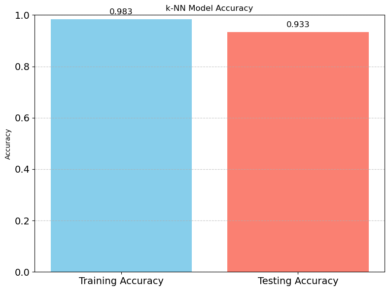

```python
# Evaluate the model
train_accuracy = np.mean(y_train_pred == y_train)
test_accuracy = np.mean(y_test_pred == y_test)
print(f'k-NN training accuracy: {train_accuracy:.3f}')
print(f'k-NN testing accuracy: {test_accuracy:.3f}')

# Plot accuracies
plt.figure(figsize=(8, 6))
accuracies = [train_accuracy, test_accuracy]
labels = ['Training Accuracy', 'Testing Accuracy']
plt.bar(labels, accuracies, color=['skyblue', 'salmon'])
plt.ylim(0, 1)
plt.ylabel('Accuracy')
plt.title('k-NN Model Accuracy')
plt.xticks(fontsize=14)
plt.yticks(fontsize=14)
for i in range(len(accuracies)):
    plt.text(i, accuracies[i] + 0.02, f'{accuracies[i]:.3f}', ha='center', fontsize=12)
plt.grid(axis='y', linestyle='--', alpha=0.7)
plt.tight_layout()
plt.show()
```

```python
# Assuming y_test and y_pred are NumPy arrays or lists
results_df = pd.DataFrame({
    'Actual': y_test,
    'Predicted': y_pred
})

# Display the DataFrame
results_df.head()
```

[output not shown]

### Question No. 2️⃣

```python
from sklearn.tree import DecisionTreeClassifier
from sklearn.metrics import accuracy_score
from sklearn.preprocessing import StandardScaler
from sklearn import tree
import matplotlib.pyplot as plt
import seaborn as sns

# Train the model
dt = DecisionTreeClassifier(random_state=42)
dt.fit(x_train, y_train)

# Predict the labels
y_pred_dt = dt.predict(x_test)

# Evaluate the model
accuracy_dt = accuracy_score(y_test, y_pred_dt)
print(f'Decision Tree accuracy: {accuracy_dt:.3f}')
```

```
Decision Tree accuracy: 0.933
```

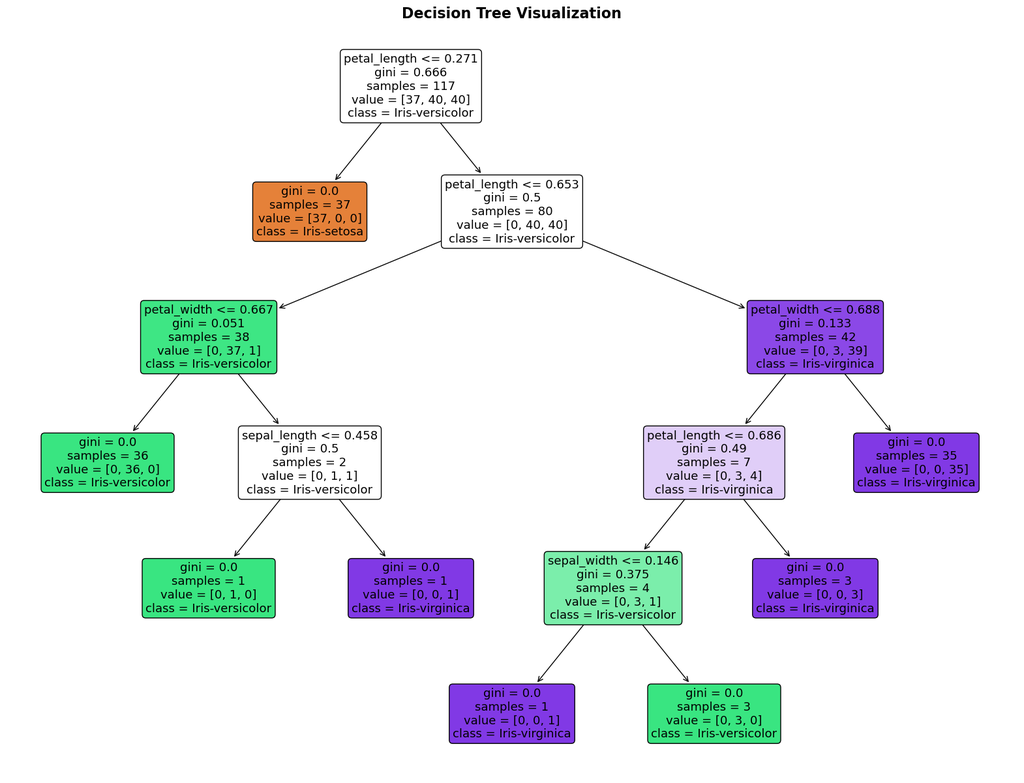

```python
# Plot the decision tree
plt.figure(figsize=(20, 15))  # Increase size for better visibility
plot_params = {
    'filled': True,
    'feature_names': iris_scaled_df.columns,
    'class_names': iris['species'].unique(),
    'fontsize': 13,
    'rounded': True,
    'precision': 3,
}

# Adjust DPI for better quality
plt.rcParams['figure.dpi'] = 100
plt.rcParams['savefig.dpi'] = 100

tree.plot_tree(dt, **plot_params)
plt.title('Decision Tree Visualization', fontsize=16, weight='bold')
plt.show()
```

### Question No. 3️⃣

```python
from sklearn.model_selection import GridSearchCV
from sklearn.ensemble import RandomForestClassifier
from sklearn.metrics import accuracy_score

# Define the parameter grid
param_grid = {
    'n_estimators': [50, 100, 200],
    'max_depth': [None, 4, 10, 20, 30],
    'min_samples_split': [2, 5, 7, 10],
    'min_samples_leaf': [2, 5, 7, 10]
}

# Initialize the Random Forest Classifier
rf = RandomForestClassifier(random_state=42)

# Perform Grid Search
grid_search = GridSearchCV(estimator=rf, param_grid=param_grid, cv=5, n_jobs=-1, verbose=3)
grid_search.fit(x_train, y_train)

# Best parameters and model
best_params = grid_search.best_params_
best_rf = grid_search.best_estimator_

print("Best Parameters:")
for param, value in best_params.items():
    print(f"{param}: {value}")
```

```
Fitting 5 folds for each of 240 candidates, totalling 1200 fits
Best Parameters:
max_depth: None
min_samples_leaf: 2
min_samples_split: 2
n_estimators: 50
```

```python
# Predict with the best model
from sklearn.metrics import accuracy_score
from sklearn.ensemble import RandomForestClassifier
rf = RandomForestClassifier(max_depth = None, min_samples_leaf = 2, min_samples_split = 2, n_estimators = 50, random_state=42)
rf.fit(x_train, y_train)

y_train_pred = rf.predict(x_train)
y_test_pred = rf.predict(x_test)
# Evaluate the model
train_accuracy = np.mean(y_train_pred == y_train)
test_accuracy = np.mean(y_test_pred == y_test)
print(f'Random Forest training accuracy: {train_accuracy:.3f}')
print(f'Random Forest testing accuracy: {test_accuracy:.3f}')
```

```
Random Forest training accuracy: 0.983
Random Forest testing accuracy: 0.933
```

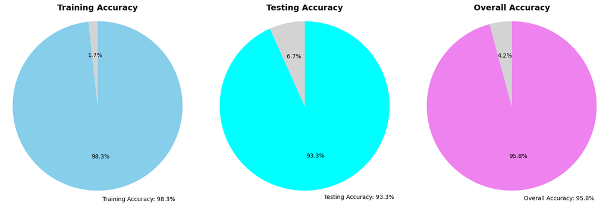

```python
# Accuracy values
train_accuracy = 0.983
test_accuracy = 0.933

# Plot accuracies as pie charts
plt.figure(figsize=(15, 5))

# Create a subplot with one row and three columns
fig, axs = plt.subplots(1, 3, figsize=(15, 5))

# Plot training accuracy
axs[0].pie([train_accuracy, 1 - train_accuracy], labels=[f'Training Accuracy: {train_accuracy * 100:.1f}%', ''], autopct='%1.1f%%', startangle=90, counterclock=False, colors=['skyblue', 'lightgray'])
axs[0].axis('equal')
axs[0].set_title('Training Accuracy', fontsize=14, weight='bold')

# Plot testing accuracy
axs[1].pie([test_accuracy, 1 - test_accuracy], labels=[f'Testing Accuracy: {test_accuracy * 100:.1f}%', ''], autopct='%1.1f%%', startangle=90, counterclock=False, colors=['cyan', 'lightgray'])
axs[1].axis('equal')
axs[1].set_title('Testing Accuracy', fontsize=14, weight='bold')

# Plot overall accuracy
overall_accuracy = (train_accuracy + test_accuracy) / 2
axs[2].pie([overall_accuracy, 1 - overall_accuracy], labels=[f'Overall Accuracy: {overall_accuracy * 100:.1f}%', ''], autopct='%1.1f%%', startangle=90, counterclock=False, colors=['violet', 'lightgray'])
axs[2].axis('equal')
axs[2].set_title('Overall Accuracy', fontsize=14, weight='bold')

plt.tight_layout()
plt.show()
```

### Question No. 4️⃣

```python
import numpy as np
import pandas as pd
import matplotlib.pyplot as plt
from mpl_toolkits.mplot3d import Axes3D
from sklearn.decomposition import PCA
from sklearn.svm import SVC
from sklearn.model_selection import train_test_split
from sklearn.preprocessing import StandardScaler
from sklearn.inspection import DecisionBoundaryDisplay
from matplotlib.colors import ListedColormap

# Load your dataset into df
df = pd.read_csv(r"C:\Users\acer\Downloads\data.csv")
```

```python
df.head()
```

|  | id | diagnosis | radius_mean | texture_mean | perimeter_mean | area_mean | smoothness_mean | compactness_mean | concavity_mean | concave points_mean | ... | radius_worst | texture_worst | perimeter_worst | area_worst | smoothness_worst | compactness_worst | concavity_worst | concave points_worst | symmetry_worst | fractal_dimension_worst |
| --- | --- | --- | --- | --- | --- | --- | --- | --- | --- | --- | --- | --- | --- | --- | --- | --- | --- | --- | --- | --- | --- |
| 0 | 842302 | M | 17.99 | 10.38 | 122.80 | 1001.0 | 0.11840 | 0.27760 | 0.3001 | 0.14710 | ... | 25.38 | 17.33 | 184.60 | 2019.0 | 0.1622 | 0.6656 | 0.7119 | 0.2654 | 0.4601 | 0.11890 |
| 1 | 842517 | M | 20.57 | 17.77 | 132.90 | 1326.0 | 0.08474 | 0.07864 | 0.0869 | 0.07017 | ... | 24.99 | 23.41 | 158.80 | 1956.0 | 0.1238 | 0.1866 | 0.2416 | 0.1860 | 0.2750 | 0.08902 |
| 2 | 84300903 | M | 19.69 | 21.25 | 130.00 | 1203.0 | 0.10960 | 0.15990 | 0.1974 | 0.12790 | ... | 23.57 | 25.53 | 152.50 | 1709.0 | 0.1444 | 0.4245 | 0.4504 | 0.2430 | 0.3613 | 0.08758 |
| 3 | 84348301 | M | 11.42 | 20.38 | 77.58 | 386.1 | 0.14250 | 0.28390 | 0.2414 | 0.10520 | ... | 14.91 | 26.50 | 98.87 | 567.7 | 0.2098 | 0.8663 | 0.6869 | 0.2575 | 0.6638 | 0.17300 |
| 4 | 84358402 | M | 20.29 | 14.34 | 135.10 | 1297.0 | 0.10030 | 0.13280 | 0.1980 | 0.10430 | ... | 22.54 | 16.67 | 152.20 | 1575.0 | 0.1374 | 0.2050 | 0.4000 | 0.1625 | 0.2364 | 0.07678 |

5 rows × 32 columns

```python
df.columns
```

```
Index(['id', 'diagnosis', 'radius_mean', 'texture_mean', 'perimeter_mean',
       'area_mean', 'smoothness_mean', 'compactness_mean', 'concavity_mean',
       'concave points_mean', 'symmetry_mean', 'fractal_dimension_mean',
       'radius_se', 'texture_se', 'perimeter_se', 'area_se', 'smoothness_se',
       'compactness_se', 'concavity_se', 'concave points_se', 'symmetry_se',
       'fractal_dimension_se', 'radius_worst', 'texture_worst',
       'perimeter_worst', 'area_worst', 'smoothness_worst',
       'compactness_worst', 'concavity_worst', 'concave points_worst',
       'symmetry_worst', 'fractal_dimension_worst'],
      dtype='object')
```

```python
# Encode categorical variables
from sklearn.preprocessing import LabelEncoder
label_encoder = LabelEncoder()
for column in df.columns:
    df[column] = label_encoder.fit_transform(df[column])


# Select only numerical columns
numerical_cols = df.select_dtypes(include=['int64', 'float64']).columns

# Create a StandardScaler object
scaler = StandardScaler()

# Fit and transform the numerical columns
df[numerical_cols] = scaler.fit_transform(df[numerical_cols])

df.head()
```

[output not shown]

5 rows × 32 columns

```python
# Selecting the required columns from the DataFrame
X = df[['perimeter_worst', 'concave points_worst', 'area_worst']].values
y = df['diagnosis'].values

# Splitting the dataset into training and testing sets
X_train, X_test, y_train, y_test = train_test_split(X, y, test_size=0.20, random_state=42)
```

```python
# Reduce the feature space to 2D using PCA
pca = PCA(n_components=3)
X_train_pca = pca.fit_transform(X_train_scaled)
X_test_pca = pca.transform(X_test_scaled)
```

```python
X_train_pca.shape
```

```
(455, 3)
```

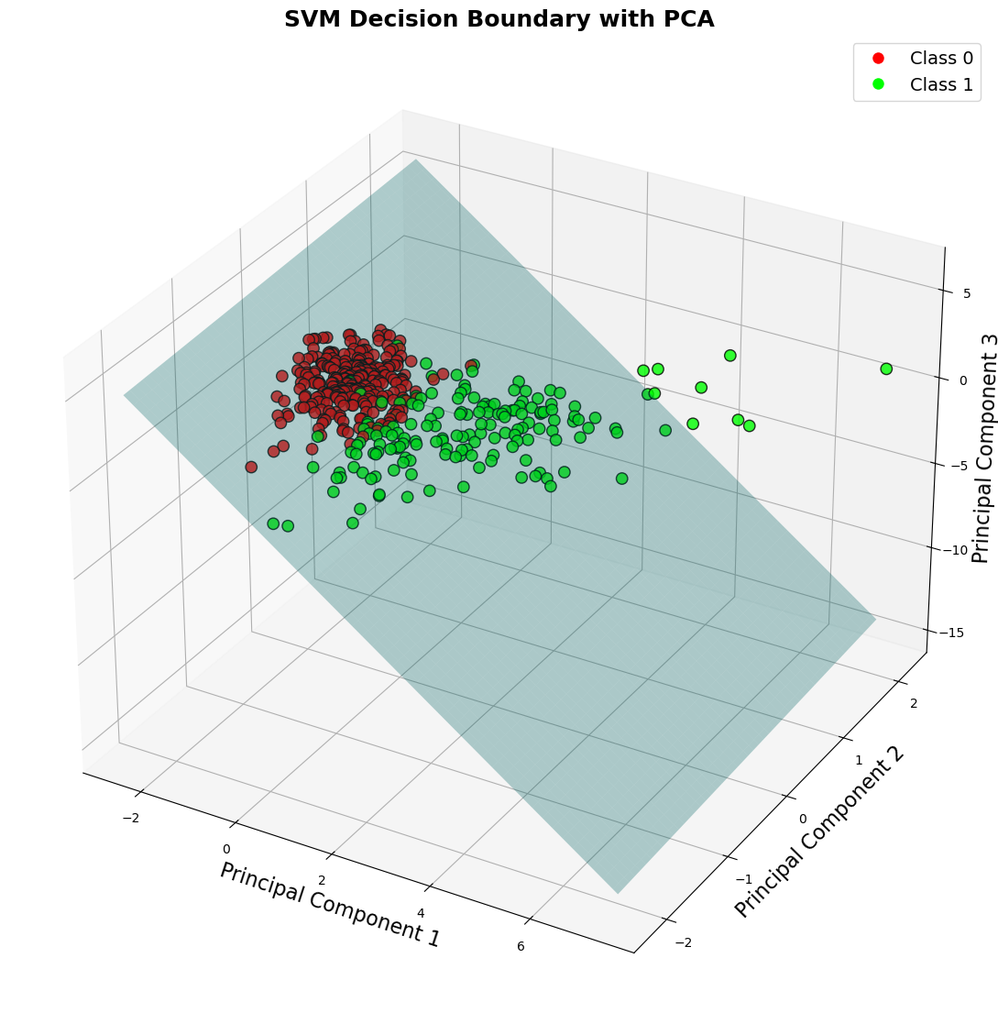

```python
# Train SVM model
svm_pca = SVC(kernel='linear')
svm_pca.fit(X_train_pca, y_train)

# Define custom color maps for better distinction
cmap_light = ListedColormap(['#FFDDDD', '#DDFFDD'])
cmap_bold = ListedColormap(['#FF0000', '#00FF00'])

# Plot decision boundary in 3D
fig = plt.figure(figsize=(11, 15))
ax = fig.add_subplot(111, projection='3d')

# Scatter plot of training data
scatter = ax.scatter(
    X_train_pca[:, 0],
    X_train_pca[:, 1],
    X_train_pca[:, 2],
    c=y_train,
    edgecolor='k',
    cmap=cmap_bold,
    marker='o',
    s=80,  # Larger size for better visibility
    alpha=0.8  # Slight transparency for better visibility
)

# Create a meshgrid for the decision boundary
xx, yy = np.meshgrid(np.linspace(X_train_pca[:, 0].min(), X_train_pca[:, 0].max(), 100),
                     np.linspace(X_train_pca[:, 1].min(), X_train_pca[:, 1].max(), 100))

# Predict decision boundary
zz = np.zeros(xx.shape)
for i in range(xx.shape[0]):
    for j in range(xx.shape[1]):
        zz[i, j] = -(svm_pca.coef_[0, 0] * xx[i, j] + svm_pca.coef_[0, 1] * yy[i, j] + svm_pca.intercept_[0]) / svm_pca.coef_[0, 2]

# Plot decision boundary surface
ax.plot_surface(xx, yy, zz, color='c', alpha=0.3)

# Customize plot
ax.set_title('SVM Decision Boundary with PCA', fontsize=18, weight='bold')
ax.set_xlabel('Principal Component 1', fontsize=16)
ax.set_ylabel('Principal Component 2', fontsize=16)
ax.set_zlabel('Principal Component 3', fontsize=16)

# Optionally add a legend for better clarity
handles = [
    plt.Line2D([0], [0], marker='o', color='w', markerfacecolor=cmap_bold(0), markersize=10, label='Class 0'),
    plt.Line2D([0], [0], marker='o', color='w', markerfacecolor=cmap_bold(1), markersize=10, label='Class 1')
]
ax.legend(handles=handles, fontsize=14)

plt.tight_layout()
plt.show()
```

[figure not shown]

```python
# Plot decision boundary in 3D
fig = plt.figure(figsize=(12, 10))
ax = fig.add_subplot(111, projection='3d')

# Scatter plot of training data
scatter = ax.scatter(
    X_train[:, 0],
    X_train[:, 1],
    np.zeros(X_train.shape[0]),  # Set z-values to zero
    c=y_train,
    edgecolor='k',
    cmap=ListedColormap(['#FFC107', '#8BC34A']),  # Use orange and green-yellow colors
    marker='D',  # Use diamond-shaped markers
    s=120,  # Larger size for better visibility
    alpha=0.8  # Slight transparency for better visibility
)

# Create a meshgrid for the decision boundary
xx, yy = np.meshgrid(np.linspace(X_train[:, 0].min(), X_train[:, 0].max(), 100),
                     np.linspace(X_train[:, 1].min(), X_train[:, 1].max(), 100))

# Predict decision boundary
zz = np.zeros(xx.shape)
for i in range(xx.shape[0]):
    for j in range(xx.shape[1]):
        zz[i, j] = -(svm.coef_[0, 0] * xx[i, j] + svm.coef_[0, 1] * yy[i, j] + svm.intercept_[0]) / svm.coef_[0, 2]

# Plot decision boundary surface
ax.plot_surface(xx, yy, zz, color='#455A64', alpha=0.4)  # Use a dark blue-gray color

# Customize plot
ax.set_title('SVM Decision Boundary in 3D', fontsize=20, weight='bold')
ax.set_xlabel('Perimeter Worst', fontsize=18)
ax.set_ylabel('Concave Points Worst', fontsize=18)
ax.set_zlabel('', fontsize=18)

# Optionally add a legend for better clarity
handles = [
    plt.Line2D([0], [0], marker='D', color='w', markerfacecolor='#FFC107', markersize=12, label='Class 0'),
    plt.Line2D([0], [0], marker='D', color='w', markerfacecolor='#8BC34A', markersize=12, label='Class 1')
]
ax.legend(handles=handles, fontsize=16, loc='upper right')

plt.tight_layout()
plt.show()
```

### Question No. 5️⃣

```python
from sklearn.feature_selection import SelectKBest, f_classif
import numpy as np
import pandas as pd
from sklearn.preprocessing import StandardScaler
from sklearn.model_selection import train_test_split, cross_val_score
from sklearn.linear_model import LogisticRegression
from sklearn.svm import SVC
from sklearn.ensemble import RandomForestClassifier
from sklearn.metrics import accuracy_score, precision_score, recall_score, f1_score, roc_auc_score, roc_curve
import matplotlib.pyplot as plt
# Select the top 5 features using ANOVA F-value

# Assuming df is your DataFrame and 'diagnosis' is the column to be separated
Y = df['diagnosis']
X = df.drop(columns=['diagnosis'], axis=1)

selector = SelectKBest(f_classif, k=5)
X_selected = selector.fit_transform(X, Y)

# Get the column names of the selected features
selected_features = X.columns[selector.get_support(indices=True)].tolist()
print("Selected Features:", selected_features)
```

```
Selected Features: ['concave points_mean', 'radius_worst', 'perimeter_worst', 'area_worst', 'concave points_worst']
```

```python
# Create a new DataFrame with the selected features
X_selected_df = pd.DataFrame(X_selected, columns=selected_features)

# Split the dataset into training and testing sets
x_train, x_test, y_train, y_test = train_test_split(X_selected_df, Y, test_size=0.2, random_state=42)
```

```python
# Initialize the classifiers
log_reg = LogisticRegression(random_state=42)
svm = SVC(probability=True, random_state=42)
rf = RandomForestClassifier(random_state=42)

# Train the classifiers
log_reg.fit(x_train, y_train)
svm.fit(x_train, y_train)
rf.fit(x_train, y_train)

# Predict the outcomes
log_reg_pred = log_reg.predict(x_test)
svm_pred = svm.predict(x_test)
rf_pred = rf.predict(x_test)

# Predict the probabilities
log_reg_proba = log_reg.predict_proba(x_test)[:, 1]
svm_proba = svm.predict_proba(x_test)[:, 1]
rf_proba = rf.predict_proba(x_test)[:, 1]
```

```python
# Define a function to print and store metrics
def print_metrics(y_true, y_pred, y_proba):
    accuracy = accuracy_score(y_true, y_pred)
    precision = precision_score(y_true, y_pred)
    recall = recall_score(y_true, y_pred)
    f1 = f1_score(y_true, y_pred)
    roc_auc = roc_auc_score(y_true, y_proba)
    return accuracy, precision, recall, f1, roc_auc

# Collect metrics for each classifier
metrics = {
    'Logistic Regression': print_metrics(y_test, log_reg_pred, log_reg_proba),
    'SVM': print_metrics(y_test, svm_pred, svm_proba),
    'Random Forest': print_metrics(y_test, rf_pred, rf_proba)
}

# Display the metrics
metrics_df = pd.DataFrame(metrics, index=['Accuracy', 'Precision', 'Recall', 'F1-score', 'ROC-AUC'])
metrics_df
```

|  | Logistic Regression | SVM | Random Forest |
| --- | --- | --- | --- |
| Accuracy | 0.964912 | 0.956140 | 0.956140 |
| Precision | 0.933333 | 0.952381 | 0.952381 |
| Recall | 0.976744 | 0.930233 | 0.930233 |
| F1-score | 0.954545 | 0.941176 | 0.941176 |
| ROC-AUC | 0.997707 | 0.997052 | 0.988536 |

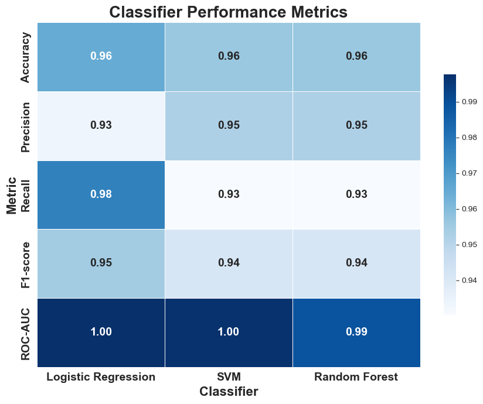

```python
# Create a heatmap for metrics comparison with lighter colors
plt.figure(figsize=(9, 7))
sns.heatmap(metrics_df, annot=True, cmap='Blues', fmt=".2f", linewidths=0.5, linecolor='white', cbar_kws={'shrink': 0.7}, annot_kws={"size": 14, "weight": "bold"})
plt.title('Classifier Performance Metrics', fontsize=20, weight='bold')
plt.xlabel('Classifier', fontsize=16, weight='bold')
plt.ylabel('Metric', fontsize=16, weight='bold')
plt.xticks(fontsize=14, weight='bold')
plt.yticks(fontsize=14, weight='bold')
plt.tight_layout()
plt.show()
```

```python
# Plot metrics comparison
import plotly.graph_objects as go

categories = metrics_df.index
values1 = metrics_df['Logistic Regression']
values2 = metrics_df['SVM']
values3 = metrics_df['Random Forest']

fig = go.Figure(data=[go.Scatterpolar(
    r=values1,
    theta=categories,
    fill='toself',
    name='Logistic Regression',
    marker=dict(color='rgba(210, 105, 230, 0.8)')
), go.Scatterpolar(
    r=values2,
    theta=categories,
    fill='toself',
    name='SVM',
    marker=dict(color='rgba(100, 149, 237, 0.8)')
), go.Scatterpolar(
    r=values3,
    theta=categories,
    fill='toself',
    name='Random Forest',
    marker=dict(color='rgba(144, 238, 144, 0.8)')
)])

fig.update_layout(
    title='Metrics Comparison',
    polar=dict(
        radialaxis=dict(
            visible=True,
            range=[0, 1]
        )
    ),
    showlegend=True,
    width=1000,
    height=800
)

fig.show()
```

[interactive chart not shown]

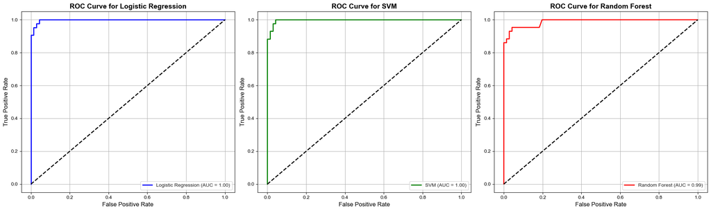

```python
fig, axs = plt.subplots(1, 3, figsize=(20, 6))
colors = ['blue', 'green', 'red']
sns.set_style("whitegrid")

for ax, name, proba, color in zip(axs, ['Logistic Regression', 'SVM', 'Random Forest'],
                                  [log_reg_proba, svm_proba, rf_proba], colors):
    fpr, tpr, _ = roc_curve(y_test, proba)
    ax.plot(fpr, tpr, label=f'{name} (AUC = {roc_auc_score(y_test, proba):.2f})', color=color, lw=2)
    ax.plot([0, 1], [0, 1], 'k--', lw=2)
    ax.set_xlabel('False Positive Rate', fontsize=12)
    ax.set_ylabel('True Positive Rate', fontsize=12)
    ax.set_title(f'ROC Curve for {name}', fontsize=14, weight='bold')
    ax.legend(loc='best', fontsize=10)
    ax.grid(True)

plt.tight_layout()
plt.show()
```

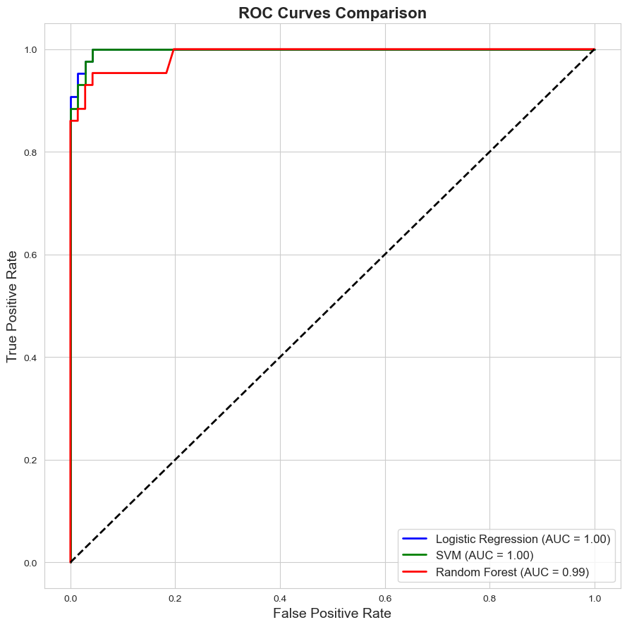

```python
# Plot ROC curves for all classifiers together
plt.figure(figsize=(9, 9))
colors = ['blue', 'green', 'red']
classifiers = ['Logistic Regression', 'SVM', 'Random Forest']
probabilities = [log_reg_proba, svm_proba, rf_proba]

for name, proba, color in zip(classifiers, probabilities, colors):
    fpr, tpr, _ = roc_curve(y_test, proba)
    plt.plot(fpr, tpr, label=f'{name} (AUC = {roc_auc_score(y_test, proba):.2f})', color=color, lw=2)

plt.plot([0, 1], [0, 1], 'k--', lw=2)
plt.xlabel('False Positive Rate', fontsize=14)
plt.ylabel('True Positive Rate', fontsize=14)
plt.title('ROC Curves Comparison', fontsize=16, weight='bold')
plt.legend(loc='best', fontsize=12)
plt.grid(True)
plt.tight_layout()
plt.show()
```